# Hard Work 3

```r
library(car)
library(mosaic)
library(ggplot2)
library(lmtest)
```

## Instructions

1. Study Sections 3.1-3.8 of Chapter 3: “Diagnostics and Remedial Measures.”  
   (We will study more of Chapter 3 next week.)
2. Attempt and submit at least {52} Hard Work Points by Saturday at 11:59 PM.  
   Over {56} gets you {+1} Final Exam Point.  
   Over {62} gets you {+2} Final Exam Points.  
   Over {70} gets you {+3} Final Exam Points.

## Reading Points {30} Possible

### Section 3.1 {2}{ 2/2}

### Section 3.2 {2}{ 1.5/2 }

### Section 3.3 {8}{ 7/8}

### Section 3.4 {2}{ 2/2 }

### Section 3.5 {2}{ 2/2 }

### Section 3.6 {6}{ 4/6 }

### Section 3.7 {7}{ 4/7 }

### Section 3.8 {1}{ 1/1 }

## Theory Points {9} Possible

### 3.1 {2}{ 2/2 }

The residual is the distance between $Y_i$ and $Yhat_i$.which is represented by $e_i = Y_i - Yhat_i$

The studentized residual is the

$$e*_i = (e_i - ebar) \div (sqrt(MSE))$$

$\sigma$ = sqrt(MES) = $\sum(Y_i - Yhat_i)/sqrt(n - 2)$

The purpose of the semistudentized residual is to simplify residuals. $e_i$ is complex because it’s for each individual error term. $e*_i$ allows you to measure according to standard deviations instead of raw measurements. This helps give perspective.

### 3.12 {2}{ / }

### 3.21 {3}{ / }

### 3.23 {2}{ / }

## Application Points {32} Possible

[Data Files](http://www.stat.ufl.edu/~rrandles/sta4210/Rclassnotes/data/textdatasets/index.html)

### 3.3 {6}{ 6/6 }

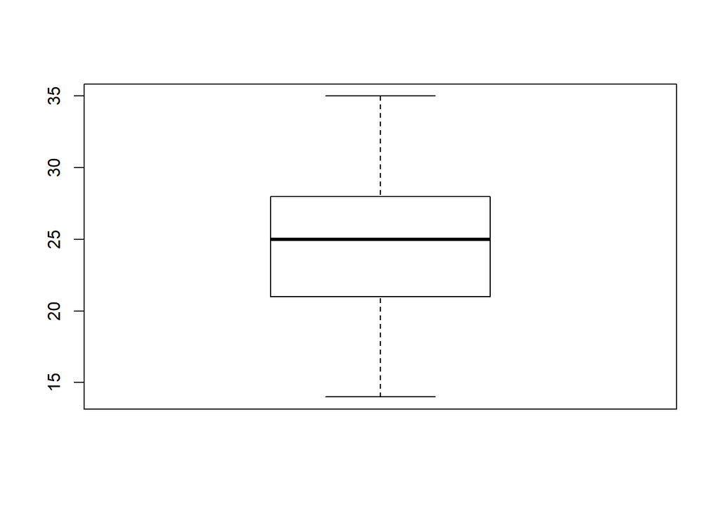

```r
# Load the Data:
p1.19 <- read.table("http://www.stat.ufl.edu/~rrandles/sta4210/Rclassnotes/data/textdatasets/KutnerData/Chapter%20%201%20Data%20Sets/CH01PR19.txt")

# Rewrite the column names to be "Y" and "X" to match the textbook:
colnames(p1.19) <- c("Y","X")

p1.19.lm <- lm(p1.19)

boxplot(p1.19$X)
```

```r
names(p1.19.lm)
```

```
##  [1] "coefficients"  "residuals"     "effects"       "rank"
##  [5] "fitted.values" "assign"        "qr"            "df.residual"
##  [9] "xlevels"       "call"          "terms"         "model"
```

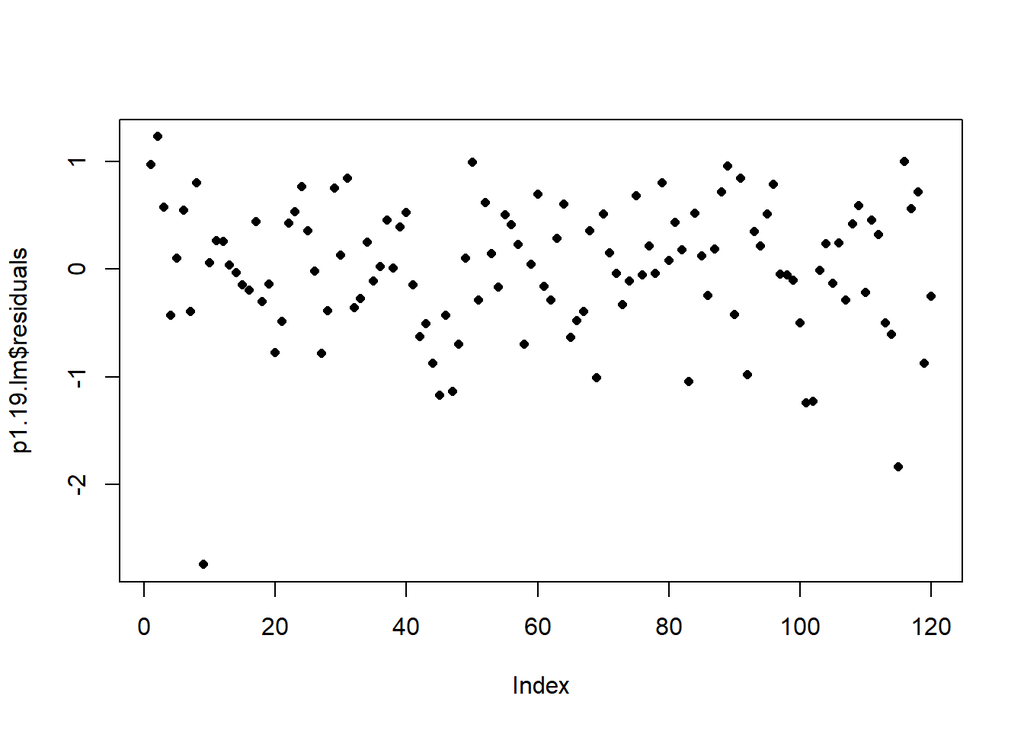

```r
plot(p1.19.lm$residuals, pch = 16, cex = 0.8)
```

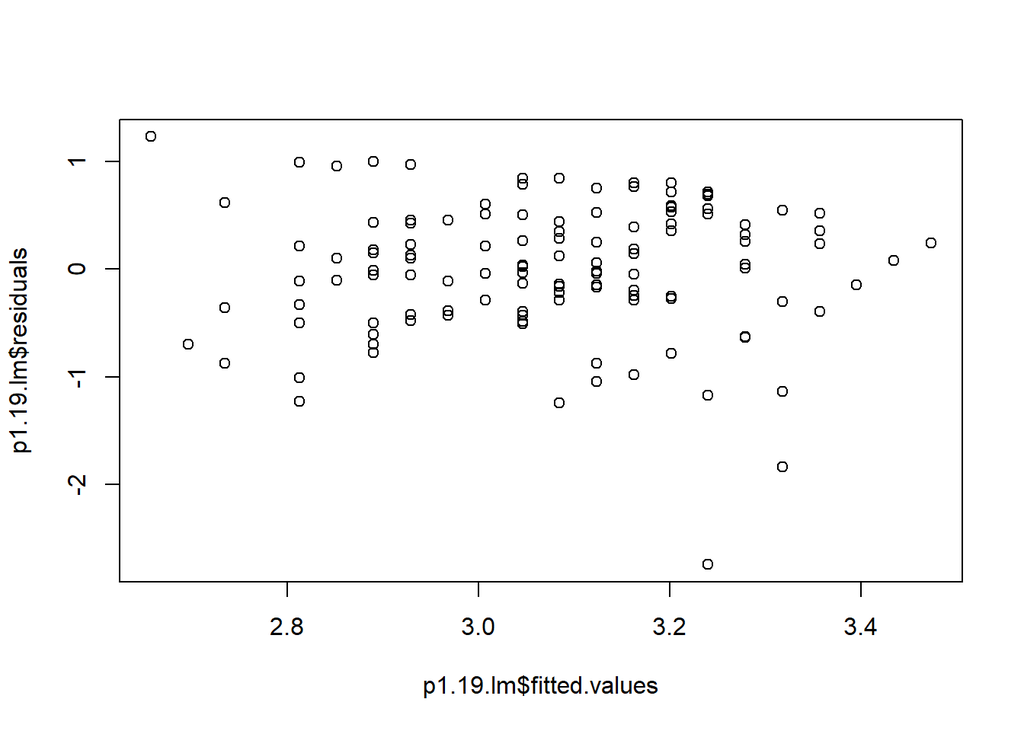

```r
plot(p1.19.lm$residuals ~ p1.19.lm$fitted.values)
```

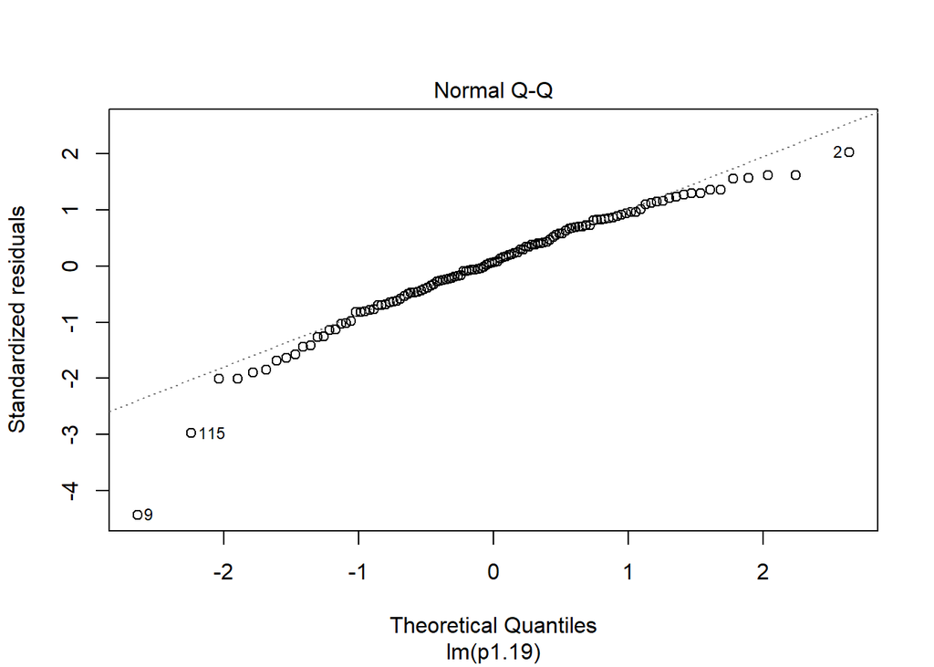

```r
plot(p1.19.lm, which  = 2:2)
```

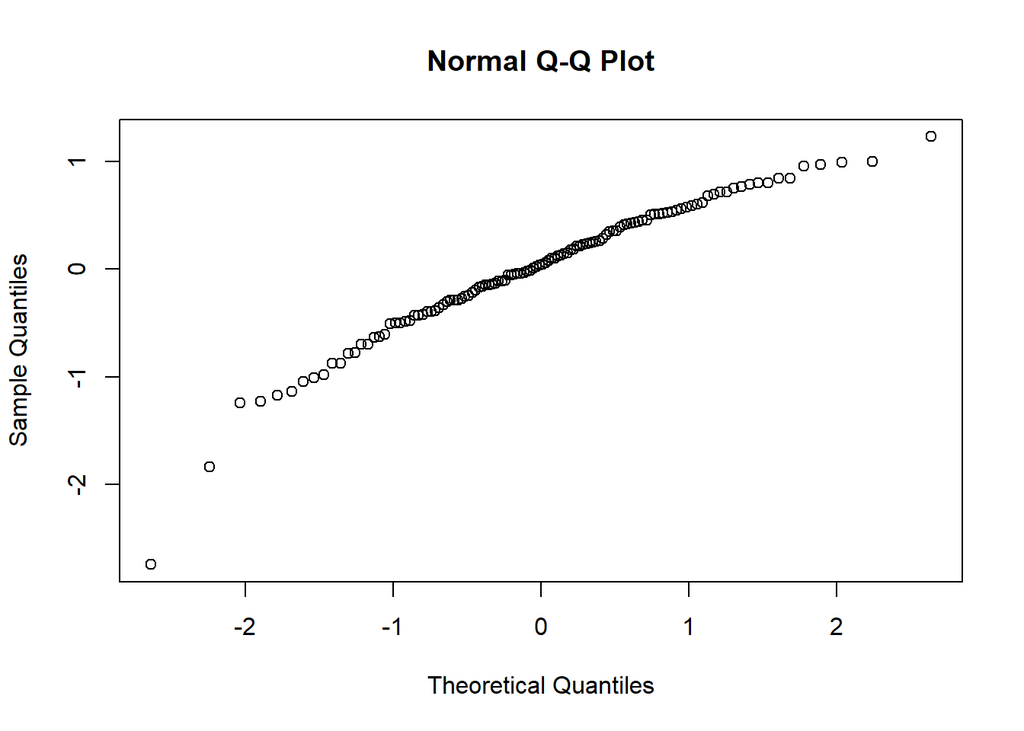

```r
qq.p1.19 <- qqnorm(p1.19.lm$residuals)
```

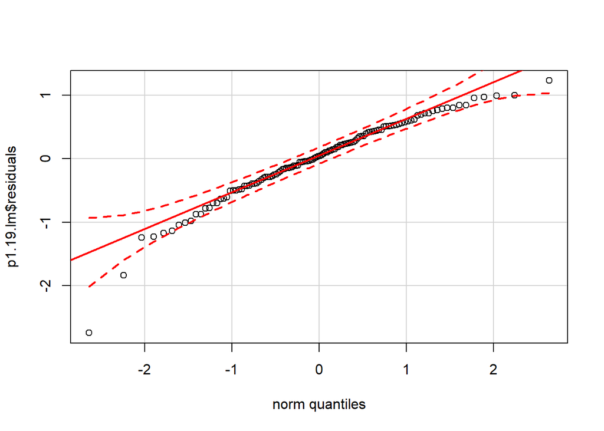

```r
qqPlot(p1.19.lm$residuals)
```

```r
names(qq.p1.19)
```

```
## [1] "x" "y"
```

```r
cor(qq.p1.19$x, qq.p1.19$y)
```

```
## [1] 0.9744497
```

```r
Group1 <- p1.19$X < 26
Group2 <- p1.19$X >= 26

med1 <- median(p1.19.lm$residuals[Group1])
med2 <- median(p1.19.lm$residuals[Group2])

d1 <- abs(p1.19.lm$residuals[Group1] - med1)
d2 <- abs(p1.19.lm$residuals[Group2] - med2)

s2BF <- ( sum((d1-mean(d1))^2) + sum((d2 - mean(d2))^2))/(120-2)
sBF <- sqrt(s2BF)
tBF <- (mean(d1) - mean(d2))/(sBF*sqrt(1/sum(Group1)+1/sum(Group2)))


qt(1-0.01/2, 120-2)
```

```
## [1] 2.618137
```

```r
tBF
```

```
## [1] -0.8967448
```

```r
2*pt(-abs(tBF), 120-2)
```

```
## [1] 0.371681
```

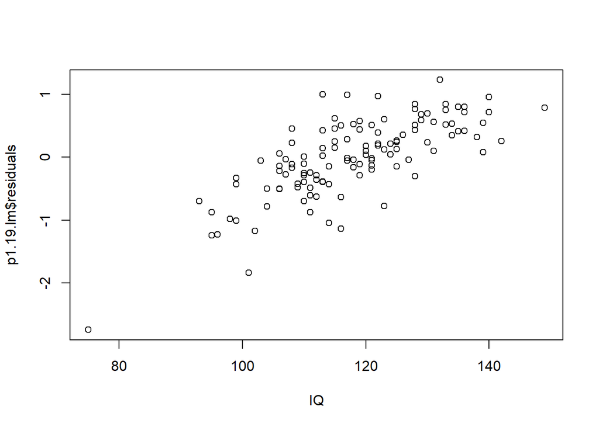

```r
p1.19extra <- read.table("http://www.stat.ufl.edu/~rrandles/sta4210/Rclassnotes/data/textdatasets/KutnerData/Chapter%20%203%20Data%20Sets/CH03PR03.txt")

colnames(p1.19extra) <- c("Y","X","X2","X3")


plot(p1.19.lm$residuals ~ p1.19extra$X2, xlab = "IQ")
```

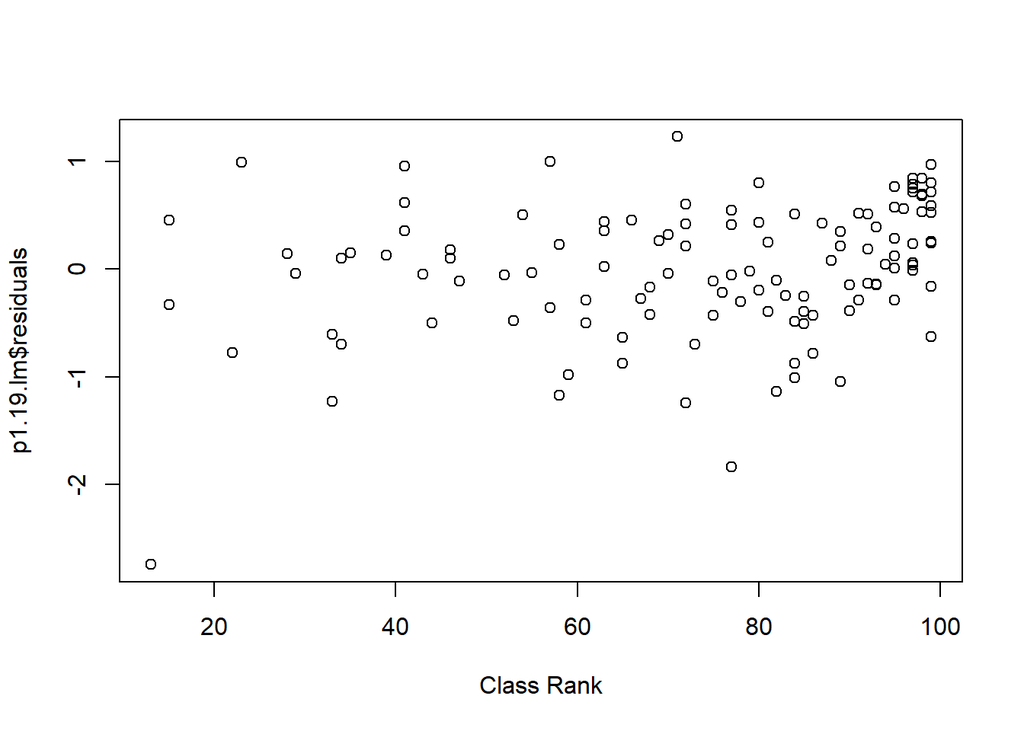

```r
plot(p1.19.lm$residuals ~ p1.19extra$X3, xlab = "Class Rank")
```

### 3.4 {6}{ 5/6 }

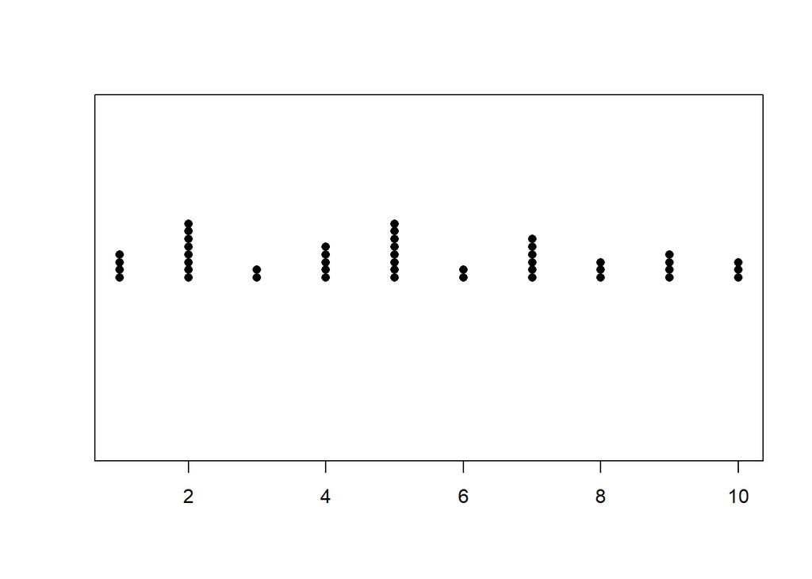

```r
# Load the Data:
p1.20 <- read.table("http://www.stat.ufl.edu/~rrandles/sta4210/Rclassnotes/data/textdatasets/KutnerData/Chapter%20%201%20Data%20Sets/CH01PR20.txt")

p1.20extra <- read.table("http://www.stat.ufl.edu/~rrandles/sta4210/Rclassnotes/data/textdatasets/KutnerData/Chapter%20%203%20Data%20Sets/CH03PR04.txt")

colnames(p1.20extra) <- c("Y","X","X2","X3")

# Rewrite the column names to be "Y" and "X" to match the textbook:
colnames(p1.20) <- c("Y","X")

p1.20.lm <- lm(p1.20)

stripchart(p1.20$X, method = 'stack', pch = 16)
```

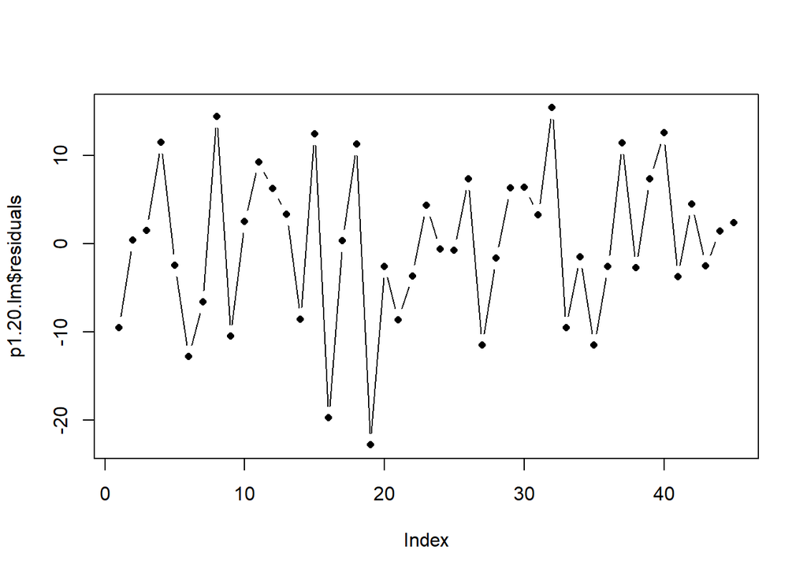

```r
plot(p1.20.lm$residuals, type = 'b', pch = 16, cex = 0.8)
```

```r
stem(p1.20.lm$residuals)
```

```
##
##   The decimal point is 1 digit(s) to the right of the |
##
##   -2 | 30
##   -1 |
##   -1 | 3110
##   -0 | 99997
##   -0 | 44333222111
##    0 | 001123334
##    0 | 5666779
##    1 | 112234
##    1 | 5
```

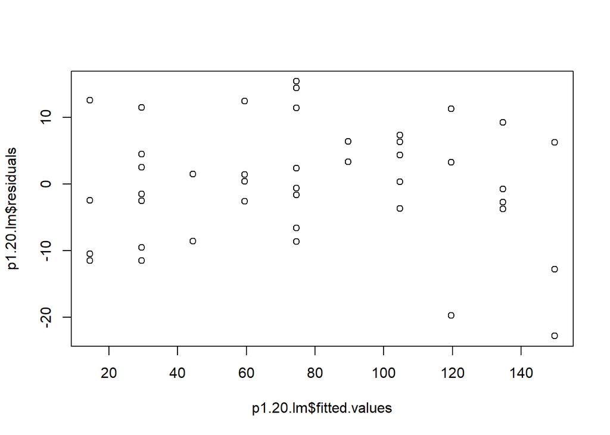

```r
plot(p1.20.lm$residuals ~ p1.20.lm$fitted.values)
```

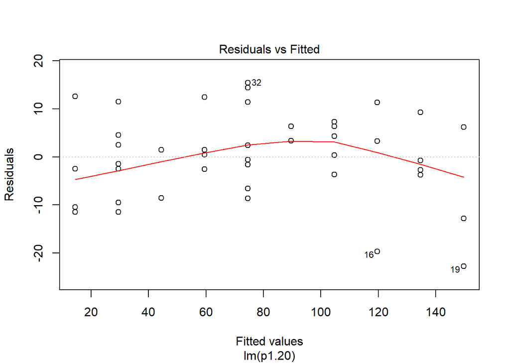

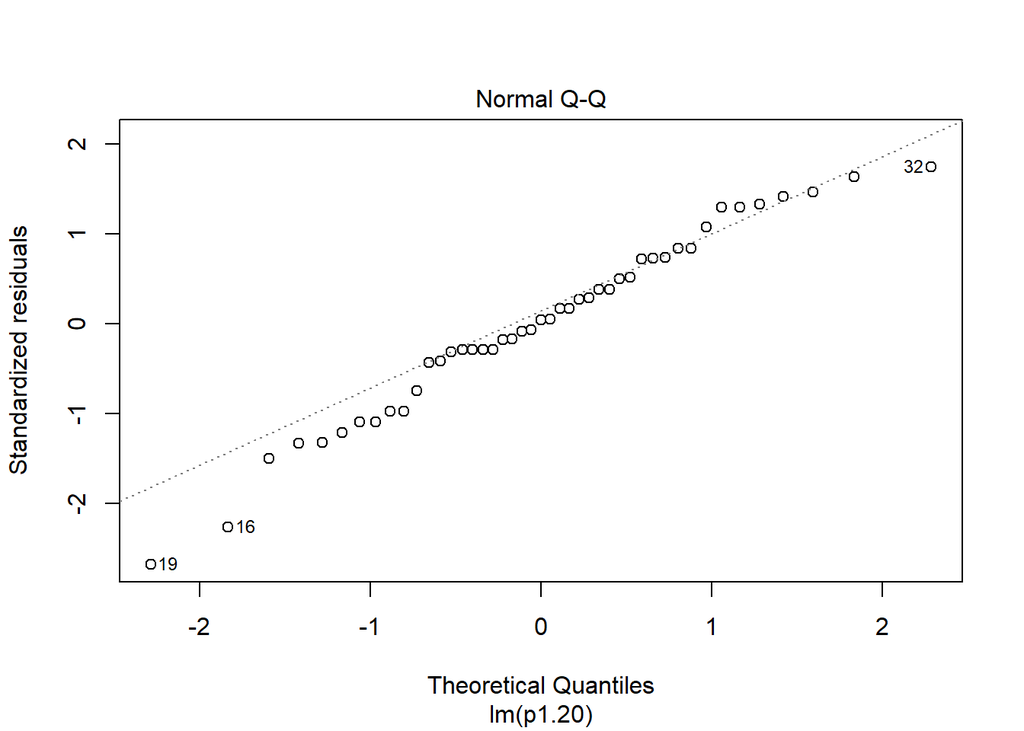

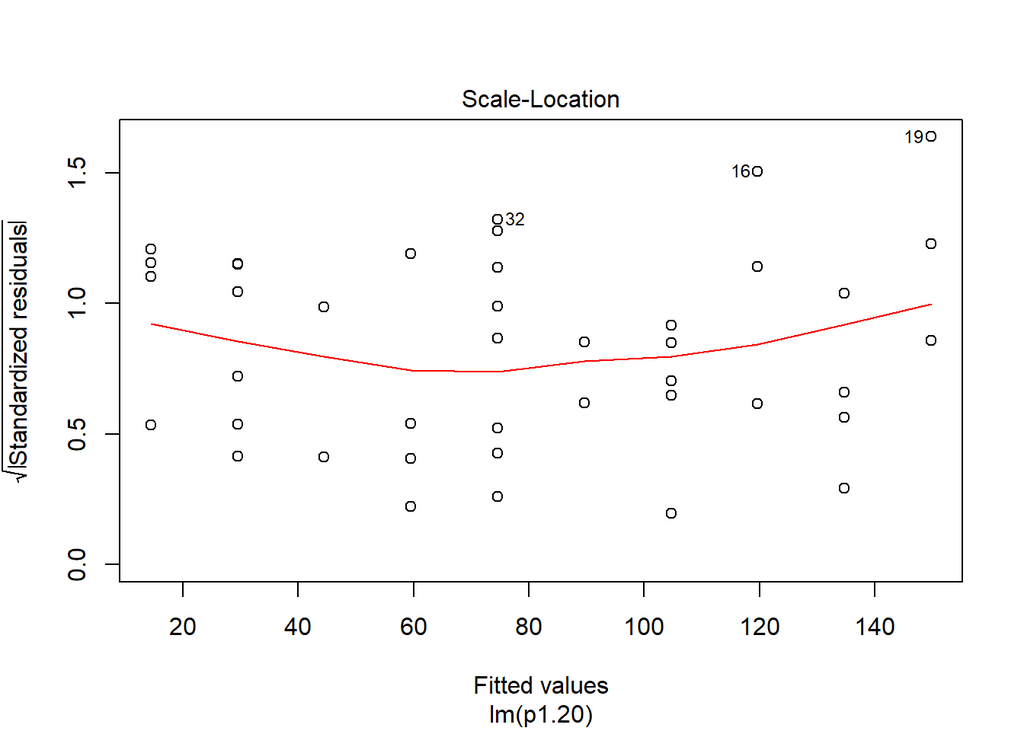

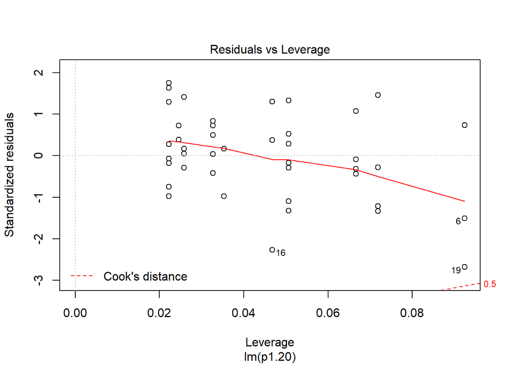

```r
plot(p1.20.lm, where = 1)
```

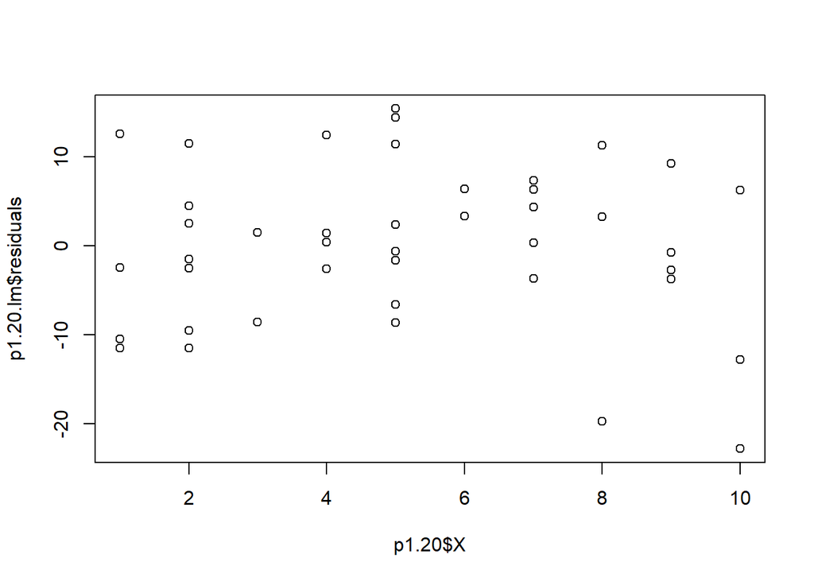

```r
plot(p1.20.lm$residuals ~ p1.20$X)
```

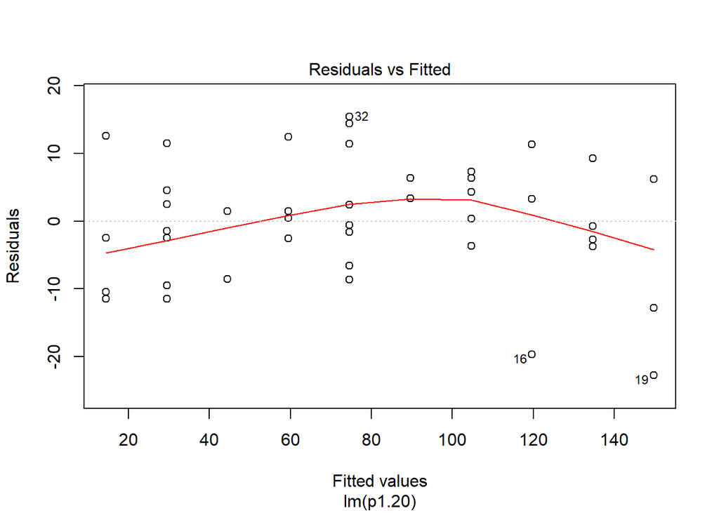

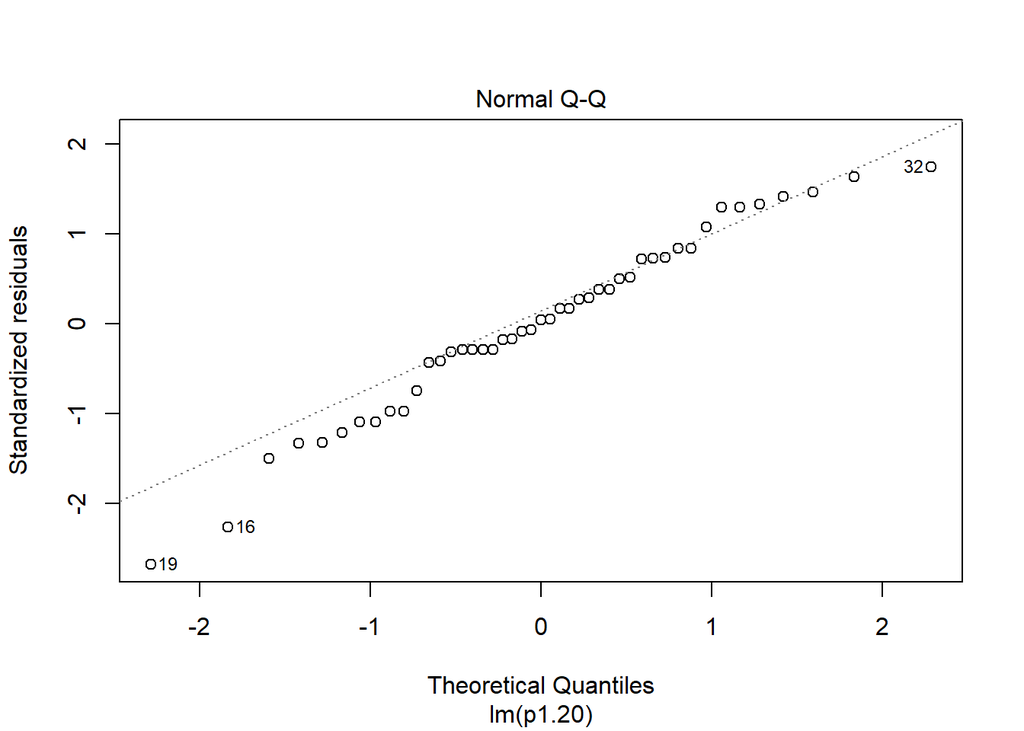

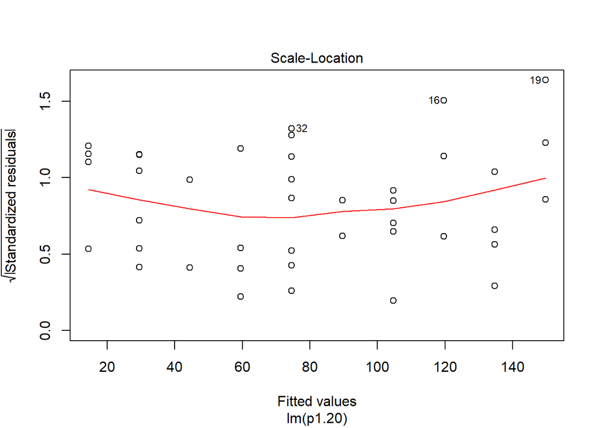

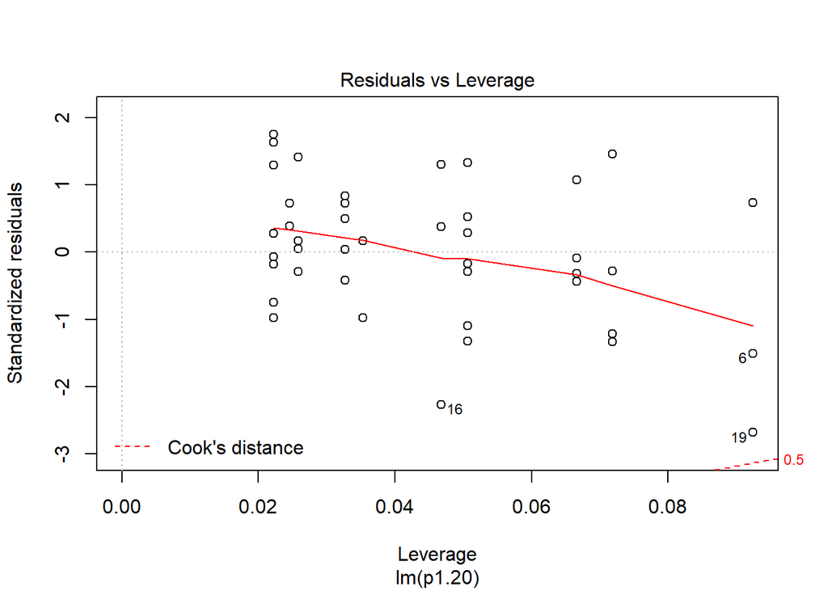

```r
plot(p1.20.lm, where = 1:3)
```

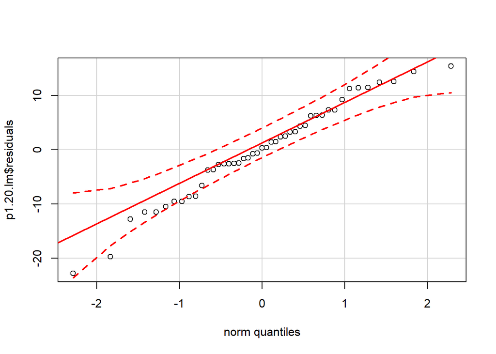

```r
qqPlot(p1.20.lm$residuals)
```

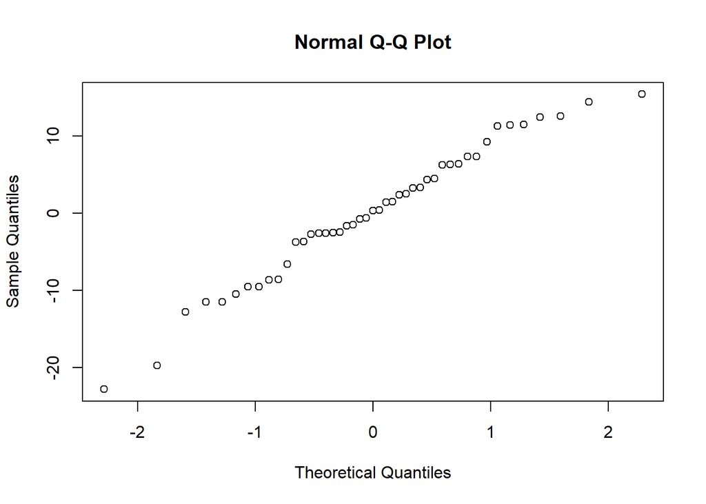

```r
qq.p1.20 <- qqnorm(p1.20.lm$residuals)
```

```r
names(qq.p1.20)
```

```
## [1] "x" "y"
```

```r
cor(qq.p1.20$x, qq.p1.20$y)
```

```
## [1] 0.9889098
```

```r
bptest(p1.20.lm)
```

```
##
##  studentized Breusch-Pagan test
##
## data:  p1.20.lm
## BP = 1.4187, df = 1, p-value = 0.2336
```

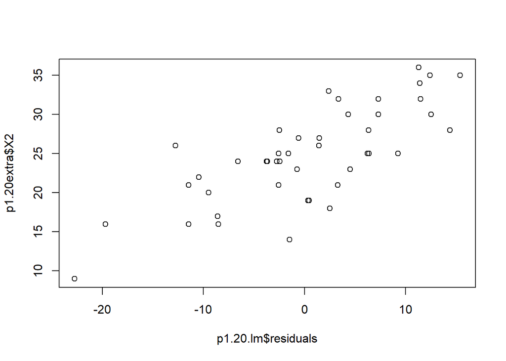

```r
plot(p1.20extra$X2 ~ p1.20.lm$residuals)
```

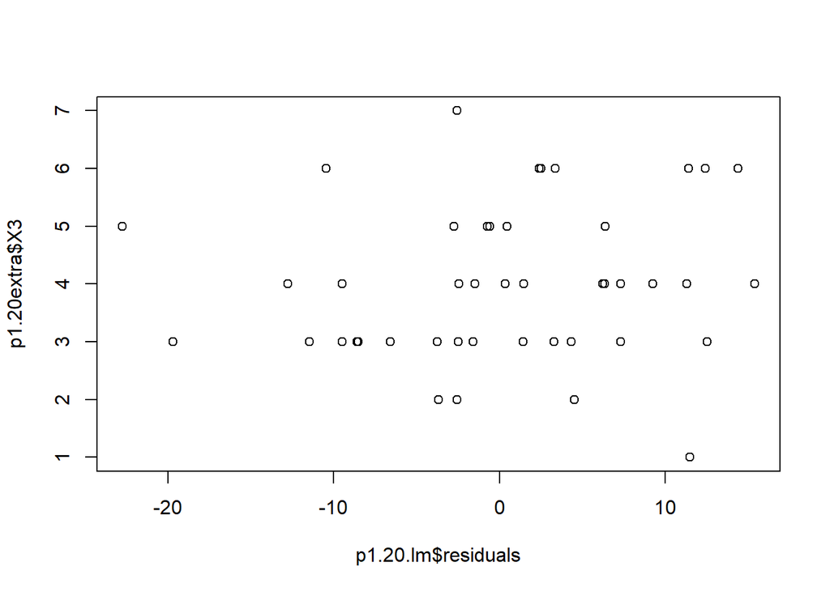

```r
plot(p1.20extra$X3 ~ p1.20.lm$residuals)
```

1. This shows that there are multiple observations with single xi values. There are no outliers.
2. This shows that the errors are independent. Time is not a factor.
3. It looks like there may be some outliers. It may also be left-skewed.
4. They do provide the same information. X and Y seem to be linear and there are no outliers.
5. Critical Value = 0.977

Correlation Coefficient = 0.9889

We conclude that the data is normal.

6. They don’t look like they’re correlated over time. There is no serious trend of increase or decrease.

because BP = 1.4187 and our p-value is 0.2336, we conclude the null.

8. In plotting these, it seems the the mean operational age of copiers serviced on the call has a significant effect on the data. It should be included.

### 3.5 {5}{ / }

```r
# Load the Data:
p1.21 <- read.table("http://www.stat.ufl.edu/~rrandles/sta4210/Rclassnotes/data/textdatasets/KutnerData/Chapter%20%201%20Data%20Sets/CH01PR21.txt")

# Rewrite the column names to be "Y" and "X" to match the textbook:
colnames(p1.21) <- c("Y","X")
```

### 3.6 {5}{ / }

```r
# Load the Data:
p1.22 <- read.table("http://www.stat.ufl.edu/~rrandles/sta4210/Rclassnotes/data/textdatasets/KutnerData/Chapter%20%201%20Data%20Sets/CH01PR22.txt")

# Rewrite the column names to be "Y" and "X" to match the textbook:
colnames(p1.22) <- c("Y","X")
```

### 3.7 {4}{ / }

```r
# Load the Data:
p1.27 <- read.table("http://www.stat.ufl.edu/~rrandles/sta4210/Rclassnotes/data/textdatasets/KutnerData/Chapter%20%201%20Data%20Sets/CH01PR27.txt")

# Rewrite the column names to be "Y" and "X" to match the textbook:
colnames(p1.27) <- c("Y","X")
```

### 3.8 {3}{ / }

```r
# Load the Data:
p1.28 <- read.table("http://www.stat.ufl.edu/~rrandles/sta4210/Rclassnotes/data/textdatasets/KutnerData/Chapter%20%201%20Data%20Sets/CH01PR28.txt")

# Rewrite the column names to be "Y" and "X" to match the textbook:
colnames(p1.28) <- c("Y","X")
```

### 3.13 {3}{ / }

```r
# Load the Data:
p1.20 <- read.table("http://www.stat.ufl.edu/~rrandles/sta4210/Rclassnotes/data/textdatasets/KutnerData/Chapter%20%201%20Data%20Sets/CH01PR20.txt")

# Rewrite the column names to be "Y" and "X" to match the textbook:
colnames(p1.20) <- c("Y","X")
```